# Problem 3 - Sales and Inventory

Taufiqur Rohman

2022-05-26

This is the last question that was given from my professor for my econometrics homework. The problem is to compare the time series linear regression, accounting auto collinearity in the model, and how to eliminate it by transforming the data. Before I start, I will upload first the “SalesInventory.xls” data that will be used for this problem. Then, I will explore a little bit about the data by plotting a graph.

```r
df_prob3 <- read_excel("~/Documents/RU/Econometrics II/HW-05-May/SalesInventory.xls")
```

```r
y <- ts(df_prob3$Sales)
x <- ts(df_prob3$Inventories)
```

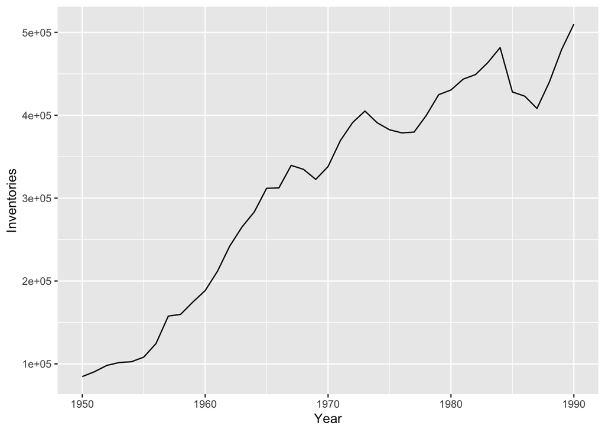

```r
graph1 <- ggplot(df_prob3, aes(x = Year, y = Inventories)) +
  geom_line() +
  xlab("Year")

graph2 <- ggplot(df_prob3, aes(x = Year, y = Sales)) +
  geom_line() +
  xlab("Year")

graph1
```

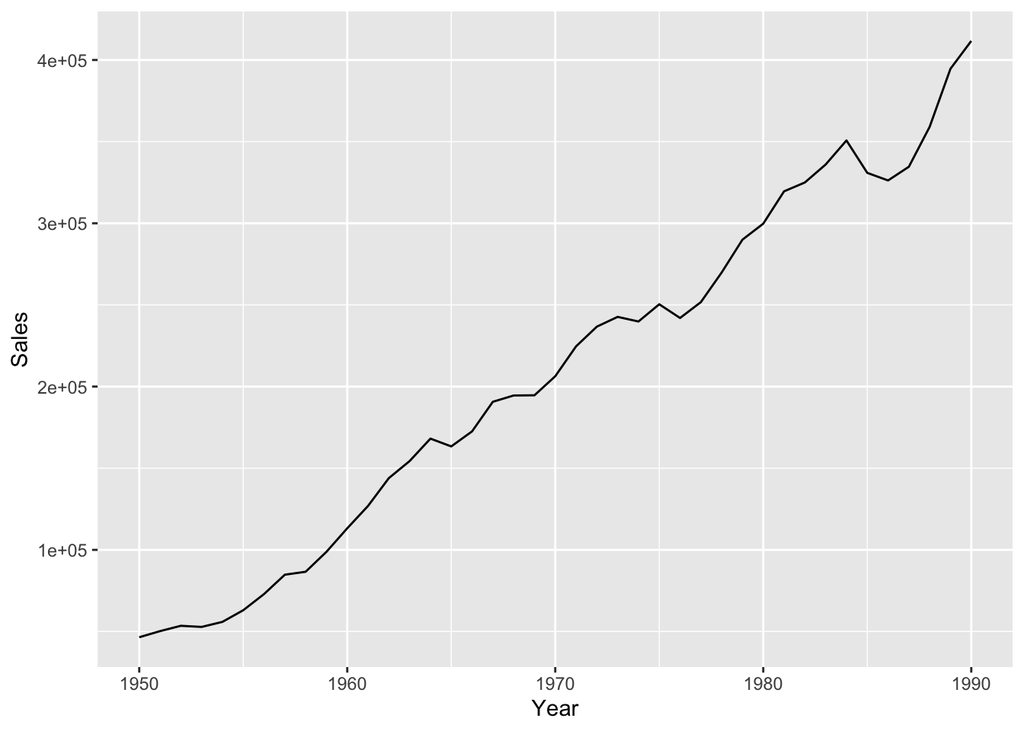

```r
graph2
```

# Problem 1

Estimate the preceding regression!

```r
p1 <- lm(Inventories ~ Sales, data = df_prob3)
summary(p1)
```

```
##
## Call:
## lm(formula = Inventories ~ Sales, data = df_prob3)
##
## Residuals:
##    Min     1Q Median     3Q    Max
## -54733 -29795   -873  25538  51798
##
## Coefficients:
##              Estimate Std. Error t value Pr(>|t|)
## (Intercept) 6.667e+04  1.090e+04   6.119 3.54e-07 ***
## Sales       1.184e+00  4.662e-02  25.396  < 2e-16 ***
## ---
## Signif. codes:  0 '***' 0.001 '**' 0.01 '*' 0.05 '.' 0.1 ' ' 1
##
## Residual standard error: 31800 on 39 degrees of freedom
## Multiple R-squared:  0.943,  Adjusted R-squared:  0.9415
## F-statistic:   645 on 1 and 39 DF,  p-value: < 2.2e-16
```

# Problem 2

From the estimated residuals find out if there is positive autocorrelation using the Durbin–Watson test and AR(1) test.

```r
p2a <- dwtest(formula = p1,  alternative = "two.sided")
p2a
```

```
##
##  Durbin-Watson test
##
## data:  p1
## DW = 0.12555, p-value < 2.2e-16
## alternative hypothesis: true autocorrelation is not 0
```

# Problem 3

If you suspect that the auto regressive error structure is of order p, how would you choose the order of p?

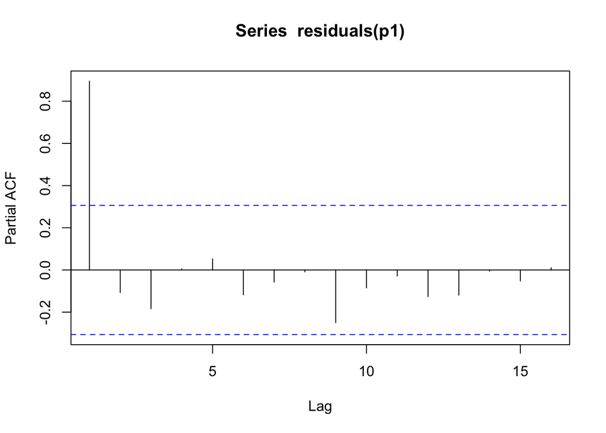

```r
pacf(residuals(p1))
```

Using partial auto correlation function (PACF) in the residual of the linear model, i found that there is an auto regressive error structure in order of p = 1.